# Comparing the microbiota of 3rd instar larvae from divergent growth conditions

Author

Anthony Grigsby

# Introduction

This document analyzes the microbiome diversity of 3rd instar larvae from different rearing groups. The analysis includes alpha diversity metrics (Observed, Shannon, Faith’s PD) and beta diversity analyses using various distance metrics (Bray-Curtis, Weighted UniFrac, Unweighted UniFrac).

## Setup

First, we load the required libraries for our analysis.

```r
library(qiime2R)
library(tidyverse)
library(ggplot2)
library(ggh4x)
library(phyloseq)
library(picante)
library(patchwork)
library(viridis)
library(rstatix)
library(vegan)
```

# Data Preparation

We create a phyloseq object from QIIME2 artifacts and filter it to include only 3rd instar larvae samples.

```r
# Make the phyloseq object and subset as necessary
# Use absolute paths to the QIIME2 artifacts
flies_ps <- qza_to_phyloseq(
  features="filtered-dada-table-nmnc.qza",
  tree="rooted-tree.qza",
  "taxonomy.qza",
  metadata = "metadata.tsv"
)

# Filter the phyloseq object to just the samples of interest
flies_ps <- subset_samples(flies_ps, Stage %in% c("3rd instar"))
flies_ps
```

```
phyloseq-class experiment-level object
otu_table()   OTU Table:         [ 2225 taxa and 60 samples ]
sample_data() Sample Data:       [ 60 samples by 13 sample variables ]
tax_table()   Taxonomy Table:    [ 2225 taxa by 7 taxonomic ranks ]
phy_tree()    Phylogenetic Tree: [ 2225 tips and 2221 internal nodes ]
```

# Alpha Diversity Analysis

Alpha diversity measures the diversity within each sample. We’ll calculate three metrics:

1. **Observed**: The number of observed ASVs (Amplicon Sequence Variants)
2. **Shannon**: Shannon diversity index, which accounts for both abundance and evenness
3. **Faith’s PD**: Phylogenetic diversity, which incorporates evolutionary relationships

## Calculate Alpha Diversity Metrics

```r
# Calculate alpha diversity metrics from phyloseq
richness <- estimate_richness(flies_ps, measures = c("Observed", "Shannon"))
# Calculate Faith's PD using picante
faith_pd <- pd(t(otu_table(flies_ps)@.Data), phy_tree(flies_ps))$PD

# Extract metadata
flies_metadata <- data.frame(sample_data(flies_ps))
flies_metadata$Sample <- rownames(flies_metadata)

# Re-factoring the RearingGroup variables
flies_metadata <- flies_metadata %>%
  mutate(Group = recode(Group,
                        "LM" = "Carcass-reared",
                        "EGG" = "Lab-reared"))

# Make the initial data frame
flies_alpha_div <- data.frame(
  Sample = sample_names(flies_ps),
  Replicate = flies_metadata$RearingGroup,
  `Rearing Group` = flies_metadata$Group,
  Observed = richness$Observed,
  Shannon = richness$Shannon,
  FaithPD = faith_pd
)

summary(flies_alpha_div)
```

```
    Sample          Replicate         Rearing.Group    Observed
 Length:60          A1-E :10   Lab-reared    :30    Min.   :17.00
 Class :character   A1-LM:10   Carcass-reared:30    1st Qu.:24.00
 Mode  :character   A2-E :10                        Median :33.50
                    A2-LM:10                        Mean   :32.95
                    A3-E :10                        3rd Qu.:40.25
                    A3-LM:10                        Max.   :57.00
    Shannon         FaithPD
 Min.   :1.459   Min.   :1.724
 1st Qu.:1.893   1st Qu.:2.436
 Median :2.264   Median :3.154
 Mean   :2.214   Mean   :3.117
 3rd Qu.:2.463   3rd Qu.:3.680
 Max.   :2.921   Max.   :5.032
```

## Reshape Data for Plotting

```r
# Facet by metric (reshape data)
flies_alpha_div_long <- flies_alpha_div %>%
  select(Sample, Replicate, Rearing.Group, Observed, Shannon, FaithPD) %>%
  pivot_longer(cols = c(Observed, Shannon, FaithPD),
               names_to = "Metric",
               values_to = "Value") %>%
  mutate(Metric = factor(Metric, levels = c("Observed", "Shannon", "FaithPD")))

# Calculate median values for each metric and Rearing Group
flies_metric_medians <- flies_alpha_div_long %>%
  group_by(Metric, Rearing.Group) %>%
  summarise(median_value = median(Value),
            .groups = "drop")
```

## Statistical Testing

We’ll use the Wilcoxon Rank-sum test to compare alpha diversity metrics between rearing groups.

```r
# Wilcoxon Rank-sum testing
stat_tests <- flies_alpha_div_long %>%
  group_by(Metric) %>%
  wilcox_test(Value ~ Rearing.Group) %>%
  adjust_pvalue(method = "bonferroni") %>%
  add_significance()

print(stat_tests)
```

```
# A tibble: 3 × 10
  Metric .y.   group1 group2    n1    n2 statistic        p   p.adj p.adj.signif
  <fct>  <chr> <chr>  <chr>  <int> <int>     <dbl>    <dbl>   <dbl> <chr>
1 Obser… Value Lab-r… Carca…    30    30       204 2.8 e- 4 8.4 e-4 ***
2 Shann… Value Lab-r… Carca…    30    30       831 4.13e-10 1.24e-9 ****
3 Faith… Value Lab-r… Carca…    30    30       138 1.09e- 6 3.27e-6 ****
```

```r
# Calculate y positions for significance annotations
y_positions <- flies_alpha_div_long %>%
  group_by(Metric) %>%
  summarise(max_val = max(Value),
            bar_y = max_val * 1.1,
            text_y = max_val * 1.15)

# Create significance annotation data frame
sig_data <- data.frame(
  Metric = c("Observed", "Shannon", "FaithPD"),
  x1 = 1,
  x2 = 2,
  label = c("***", "****", "****")
)
```

## Alpha Diversity Visualization

We’ll create boxplots for each alpha diversity metric, comparing the rearing groups.

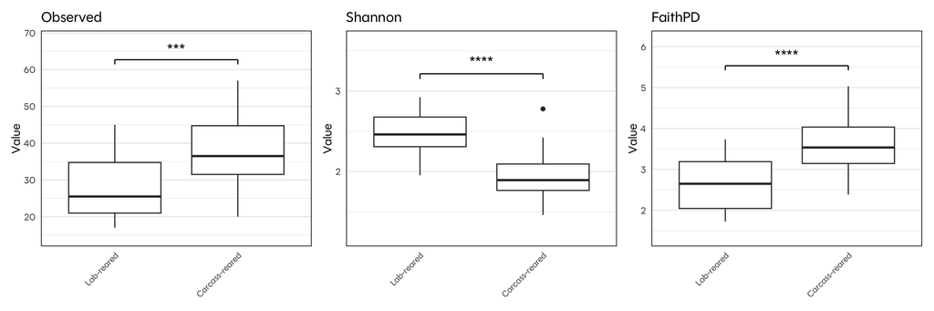

```r
# Create separate plots for each metric to ensure correct order
p_observed <- flies_alpha_div_long %>%
  filter(Metric == "Observed") %>%
  ggplot(aes(x = Rearing.Group, y = Value)) +
  geom_boxplot() +
  # Add significance annotations for Observed
  geom_segment(data = sig_data %>% filter(Metric == "Observed"),
               aes(x = x1, xend = x2,
                   y = y_positions$bar_y[y_positions$Metric == "Observed"],
                   yend = y_positions$bar_y[y_positions$Metric == "Observed"]),
               color = "black") +
  geom_segment(data = sig_data %>% filter(Metric == "Observed"),
               aes(x = x1, xend = x1,
                   y = y_positions$bar_y[y_positions$Metric == "Observed"] * 0.98,
                   yend = y_positions$bar_y[y_positions$Metric == "Observed"]),
               color = "black") +
  geom_segment(data = sig_data %>% filter(Metric == "Observed"),
               aes(x = x2, xend = x2,
                   y = y_positions$bar_y[y_positions$Metric == "Observed"] * 0.98,
                   yend = y_positions$bar_y[y_positions$Metric == "Observed"]),
               color = "black") +
  geom_text(data = sig_data %>% filter(Metric == "Observed"),
            aes(x = 1.5,
                y = y_positions$text_y[y_positions$Metric == "Observed"],
                label = label),
            size = 5) +
  theme_minimal() +
  theme(
    text = element_text(family = "Polymath"),
    axis.text.x = element_text(angle = 45, hjust = 1, size = 8, family = "Polymath"),
    axis.text.y = element_text(family = "Polymath"),
    strip.text = element_text(size = 12, face = "bold", family = "Polymath"),
    panel.spacing = unit(0.2, "cm"),
    axis.title.y = element_text(margin = margin(r = 1), family = "Polymath"),
    panel.grid.major.x = element_blank(),
    panel.border = element_rect(color = "black", fill = NA, linewidth = 0.6),
    legend.position = "none"
  ) +
  labs(x = NULL,
       y = "Value",
       title = "Observed") +
  scale_y_continuous(expand = c(0.1, 0.2))

p_shannon <- flies_alpha_div_long %>%
  filter(Metric == "Shannon") %>%
  ggplot(aes(x = Rearing.Group, y = Value)) +
  geom_boxplot() +
  # Add significance annotations for Shannon
  geom_segment(data = sig_data %>% filter(Metric == "Shannon"),
               aes(x = x1, xend = x2,
                   y = y_positions$bar_y[y_positions$Metric == "Shannon"],
                   yend = y_positions$bar_y[y_positions$Metric == "Shannon"]),
               color = "black") +
  geom_segment(data = sig_data %>% filter(Metric == "Shannon"),
               aes(x = x1, xend = x1,
                   y = y_positions$bar_y[y_positions$Metric == "Shannon"] * 0.98,
                   yend = y_positions$bar_y[y_positions$Metric == "Shannon"]),
               color = "black") +
  geom_segment(data = sig_data %>% filter(Metric == "Shannon"),
               aes(x = x2, xend = x2,
                   y = y_positions$bar_y[y_positions$Metric == "Shannon"] * 0.98,
                   yend = y_positions$bar_y[y_positions$Metric == "Shannon"]),
               color = "black") +
  geom_text(data = sig_data %>% filter(Metric == "Shannon"),
            aes(x = 1.5,
                y = y_positions$text_y[y_positions$Metric == "Shannon"],
                label = label),
            size = 5) +
  theme_minimal() +
  theme(
    text = element_text(family = "Polymath"),
    axis.text.x = element_text(angle = 45, hjust = 1, size = 8, family = "Polymath"),
    axis.text.y = element_text(family = "Polymath"),
    strip.text = element_text(size = 12, face = "bold", family = "Polymath"),
    panel.spacing = unit(0.2, "cm"),
    axis.title.y = element_text(margin = margin(r = 1), family = "Polymath"),
    panel.grid.major.x = element_blank(),
    panel.border = element_rect(color = "black", fill = NA, linewidth = 0.6),
    legend.position = "none"
  ) +
  labs(x = NULL,
       y = "Value",
       title = "Shannon") +
  scale_y_continuous(expand = c(0.1, 0.2))

p_faithpd <- flies_alpha_div_long %>%
  filter(Metric == "FaithPD") %>%
  ggplot(aes(x = Rearing.Group, y = Value)) +
  geom_boxplot() +
  # Add significance annotations for FaithPD
  geom_segment(data = sig_data %>% filter(Metric == "FaithPD"),
               aes(x = x1, xend = x2,
                   y = y_positions$bar_y[y_positions$Metric == "FaithPD"],
                   yend = y_positions$bar_y[y_positions$Metric == "FaithPD"]),
               color = "black") +
  geom_segment(data = sig_data %>% filter(Metric == "FaithPD"),
               aes(x = x1, xend = x1,
                   y = y_positions$bar_y[y_positions$Metric == "FaithPD"] * 0.98,
                   yend = y_positions$bar_y[y_positions$Metric == "FaithPD"]),
               color = "black") +
  geom_segment(data = sig_data %>% filter(Metric == "FaithPD"),
               aes(x = x2, xend = x2,
                   y = y_positions$bar_y[y_positions$Metric == "FaithPD"] * 0.98,
                   yend = y_positions$bar_y[y_positions$Metric == "FaithPD"]),
               color = "black") +
  geom_text(data = sig_data %>% filter(Metric == "FaithPD"),
            aes(x = 1.5,
                y = y_positions$text_y[y_positions$Metric == "FaithPD"],
                label = label),
            size = 5) +
  theme_minimal() +
  theme(
    text = element_text(family = "Polymath"),
    axis.text.x = element_text(angle = 45, hjust = 1, size = 8, family = "Polymath"),
    axis.text.y = element_text(family = "Polymath"),
    strip.text = element_text(size = 12, face = "bold", family = "Polymath"),
    panel.spacing = unit(0.2, "cm"),
    axis.title.y = element_text(margin = margin(r = 1), family = "Polymath"),
    panel.grid.major.x = element_blank(),
    panel.border = element_rect(color = "black", fill = NA, linewidth = 0.6),
    legend.position = "none"
  ) +
  labs(x = NULL,
       y = "Value",
       title = "FaithPD") +
  scale_y_continuous(expand = c(0.1, 0.2))

# Combine plots in the exact order you want using patchwork
p1 <- p_observed + p_shannon + p_faithpd + plot_layout(nrow = 1)
p1
```

## Sample-Level Alpha Diversity

Now we’ll visualize the alpha diversity values for each individual sample, grouped by rearing group.

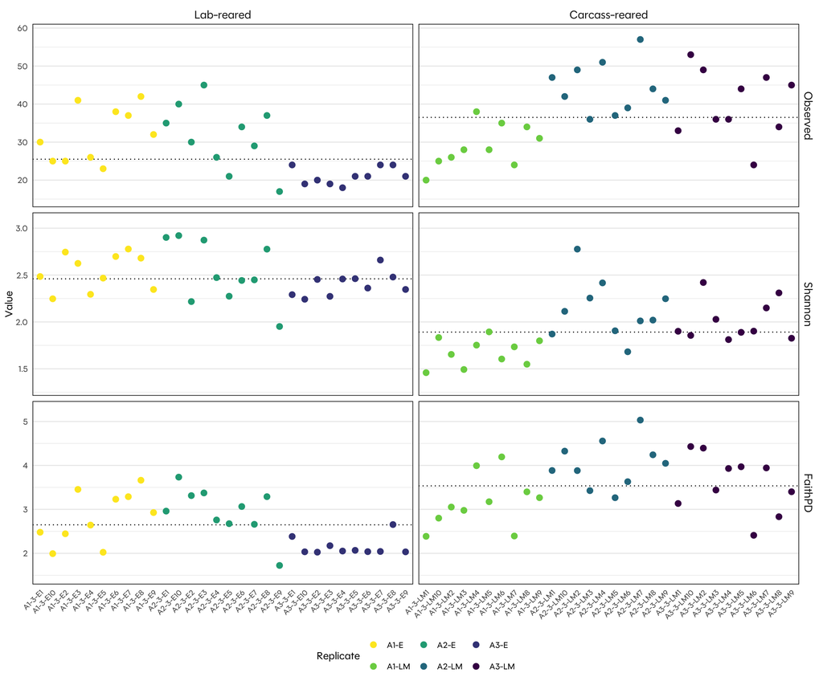

```r
# Sample-level alpha diversity plot
p2 <- ggplot(flies_alpha_div_long, aes(x = Sample, y = Value)) +
  geom_hline(data = flies_metric_medians,
             aes(yintercept = median_value),
             linetype = "dotted",
             color = "black") +
  geom_point(aes(color = Replicate), size = 3, shape = 16) +
  facet_grid(Metric ~ Rearing.Group, scales = "free") +
  theme_minimal() +
  theme(
    text = element_text(family = "Polymath"),
    axis.text.x = element_text(angle = 45, hjust = 1, size = 8, family = "Polymath"),
    axis.text.y = element_text(family = "Polymath"),
    strip.text = element_text(size = 12, face = "bold", family = "Polymath"),
    panel.spacing = unit(0.2, "cm"),
    axis.title.y = element_text(margin = margin(r = 1), family = "Polymath"),
    panel.grid.major.x = element_blank(),
    panel.border = element_rect(color = "black", fill = NA, linewidth = 0.6),
    legend.position = "bottom",
    legend.text = element_text(family = "Polymath"),
    legend.title = element_text(family = "Polymath")
  ) +
  labs(x = NULL,
       y = "Value",
       color = "Replicate") +
  scale_y_continuous(expand = c(0.1, 0.1)) +
  scale_color_viridis_d(direction = -1)

p2
```

## Combined Alpha Diversity Plots

We’ll combine the boxplots and sample-level plots into a single figure.

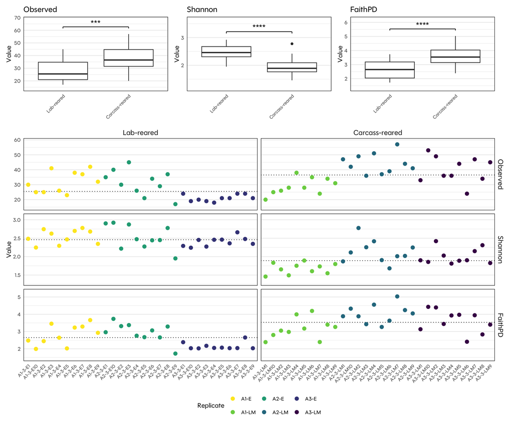

```r
# Combine plots vertically
alpha_plot <- p1 / p2 + plot_layout(heights = c(1, 3))
alpha_plot
```

# Beta Diversity Analysis

Beta diversity measures the differences in microbial community composition between samples. We’ll use three distance metrics:

1. **Bray-Curtis**: Based on abundance data
2. **Weighted UniFrac**: Incorporates phylogenetic distances and abundance
3. **Unweighted UniFrac**: Incorporates phylogenetic distances but not abundance

## Calculate Distance Matrices

```r
# Extract metadata
fly_metadata <- data.frame(sample_data(flies_ps))

# Calculate distances
w_unifrac_dist <- UniFrac(flies_ps, weighted = TRUE)
uw_unifrac_dist <- UniFrac(flies_ps, weighted = FALSE)
bray_dist <- vegdist(t(otu_table(flies_ps)@.Data), method = "bray")

# Perform ordinations
w_unifrac <- ordinate(flies_ps, method = "PCoA", distance = w_unifrac_dist)
uw_unifrac <- ordinate(flies_ps, method = "PCoA", distance = uw_unifrac_dist)
bray_ord <- ordinate(flies_ps, method = "PCoA", distance = bray_dist)
```

## Prepare Data for Plotting

```r
# Create data frames for plotting
w_df <- data.frame(
  PC1 = w_unifrac$vectors[,1],
  PC2 = w_unifrac$vectors[,2],
  Sample = sample_names(flies_ps),
  Replicate = flies_metadata$RearingGroup,
  `Rearing Group` = flies_metadata$Group
)

uw_df <- data.frame(
  PC1 = uw_unifrac$vectors[,1],
  PC2 = uw_unifrac$vectors[,2],
  Sample = sample_names(flies_ps),
  Replicate = flies_metadata$RearingGroup,
  `Rearing Group` = flies_metadata$Group
)

bray_df <- data.frame(
  PC1 = bray_ord$vectors[,1],
  PC2 = bray_ord$vectors[,2],
  Sample = sample_names(flies_ps),
  Replicate = flies_metadata$RearingGroup,
  `Rearing Group` = flies_metadata$Group
)

# Calculate variance explained
w_var <- round(w_unifrac$values$Relative_eig * 100, 1)
uw_var <- round(uw_unifrac$values$Relative_eig * 100, 1)
bray_var <- round(bray_ord$values$Relative_eig * 100, 1)
```

## Beta Diversity Statistical Tests

We’ll perform two types of statistical tests:

1. **Beta dispersion**: Tests if the dispersion (variability) of samples differs between groups
2. **PERMANOVA**: Tests if the centroids of groups differ significantly

```r
# Perform beta dispersion tests
# Weighted UniFrac
w_beta_disp_replicate <- betadisper(w_unifrac_dist, flies_metadata$RearingGroup)
w_beta_disp_rearing_group <- betadisper(w_unifrac_dist, flies_metadata$Group)

# Unweighted UniFrac
uw_beta_disp_replicate <- betadisper(uw_unifrac_dist, flies_metadata$RearingGroup)
uw_beta_disp_rearing_group <- betadisper(uw_unifrac_dist, flies_metadata$Group)

# Bray-Curtis
bray_beta_disp_replicate <- betadisper(bray_dist, flies_metadata$RearingGroup)
bray_beta_disp_rearing_group <- betadisper(bray_dist, flies_metadata$Group)

# Print beta dispersion test results
cat("Beta dispersion test results:\n")
```

```
Beta dispersion test results:
```

```r
cat("\nBray-Curtis:\n")
```

```
Bray-Curtis:
```

```r
cat("Replicate:\n")
```

```
Replicate:
```

```r
print(permutest(bray_beta_disp_replicate))
```

```
Permutation test for homogeneity of multivariate dispersions
Permutation: free
Number of permutations: 999

Response: Distances
          Df  Sum Sq  Mean Sq      F N.Perm Pr(>F)
Groups     5 0.27060 0.054120 5.7467    999  0.001 ***
Residuals 54 0.50855 0.009418
---
Signif. codes:  0 '***' 0.001 '**' 0.01 '*' 0.05 '.' 0.1 ' ' 1
```

```r
cat("Rearing Group:\n")
```

```
Rearing Group:
```

```r
print(permutest(bray_beta_disp_rearing_group))
```

```
Permutation test for homogeneity of multivariate dispersions
Permutation: free
Number of permutations: 999

Response: Distances
          Df  Sum Sq  Mean Sq     F N.Perm Pr(>F)
Groups     1 0.11999 0.119989 14.94    999  0.002 **
Residuals 58 0.46583 0.008031
---
Signif. codes:  0 '***' 0.001 '**' 0.01 '*' 0.05 '.' 0.1 ' ' 1
```

```r
cat("\nWeighted UniFrac:\n")
```

```
Weighted UniFrac:
```

```r
cat("Replicate:\n")
```

```
Replicate:
```

```r
print(permutest(w_beta_disp_replicate))
```

```
Permutation test for homogeneity of multivariate dispersions
Permutation: free
Number of permutations: 999

Response: Distances
          Df     Sum Sq    Mean Sq      F N.Perm Pr(>F)
Groups     5 5.6894e-05 1.1379e-05 6.0952    999  0.001 ***
Residuals 54 1.0081e-04 1.8668e-06
---
Signif. codes:  0 '***' 0.001 '**' 0.01 '*' 0.05 '.' 0.1 ' ' 1
```

```r
cat("Rearing Group:\n")
```

```
Rearing Group:
```

```r
print(permutest(w_beta_disp_rearing_group))
```

```
Permutation test for homogeneity of multivariate dispersions
Permutation: free
Number of permutations: 999

Response: Distances
          Df     Sum Sq    Mean Sq      F N.Perm Pr(>F)
Groups     1 1.3800e-07 1.3819e-07 0.0563    999  0.806
Residuals 58 1.4235e-04 2.4543e-06
```

```r
cat("\nUnweighted UniFrac:\n")
```

```
Unweighted UniFrac:
```

```r
cat("Replicate:\n")
```

```
Replicate:
```

```r
print(permutest(uw_beta_disp_replicate))
```

```
Permutation test for homogeneity of multivariate dispersions
Permutation: free
Number of permutations: 999

Response: Distances
          Df  Sum Sq  Mean Sq      F N.Perm Pr(>F)
Groups     5 0.35187 0.070374 2.7272    999  0.032 *
Residuals 54 1.39344 0.025804
---
Signif. codes:  0 '***' 0.001 '**' 0.01 '*' 0.05 '.' 0.1 ' ' 1
```

```r
cat("Rearing Group:\n")
```

```
Rearing Group:
```

```r
print(permutest(uw_beta_disp_rearing_group))
```

```
Permutation test for homogeneity of multivariate dispersions
Permutation: free
Number of permutations: 999

Response: Distances
          Df  Sum Sq  Mean Sq     F N.Perm Pr(>F)
Groups     1 0.03765 0.037647 3.624    999  0.054 .
Residuals 58 0.60253 0.010388
---
Signif. codes:  0 '***' 0.001 '**' 0.01 '*' 0.05 '.' 0.1 ' ' 1
```

```r
# Perform PERMANOVA tests
cat("\nPERMANOVA results:\n")
```

```
PERMANOVA results:
```

```r
cat("\nBray-Curtis:\n")
```

```
Bray-Curtis:
```

```r
cat("Replicate:\n")
```

```
Replicate:
```

```r
print(adonis2(bray_dist ~ RearingGroup, data = flies_metadata))
```

```
Permutation test for adonis under reduced model
Permutation: free
Number of permutations: 999

adonis2(formula = bray_dist ~ RearingGroup, data = flies_metadata)
         Df SumOfSqs      R2      F Pr(>F)
Model     5  10.7768 0.67773 22.712  0.001 ***
Residual 54   5.1246 0.32227
Total    59  15.9015 1.00000
---
Signif. codes:  0 '***' 0.001 '**' 0.01 '*' 0.05 '.' 0.1 ' ' 1
```

```r
cat("Rearing Group:\n")
```

```
Rearing Group:
```

```r
print(adonis2(bray_dist ~ Group, data = flies_metadata))
```

```
Permutation test for adonis under reduced model
Permutation: free
Number of permutations: 999

adonis2(formula = bray_dist ~ Group, data = flies_metadata)
         Df SumOfSqs     R2      F Pr(>F)
Model     1   7.5483 0.4747 52.412  0.001 ***
Residual 58   8.3531 0.5253
Total    59  15.9015 1.0000
---
Signif. codes:  0 '***' 0.001 '**' 0.01 '*' 0.05 '.' 0.1 ' ' 1
```

```r
cat("\nWeighted UniFrac:\n")
```

```
Weighted UniFrac:
```

```r
cat("Replicate:\n")
```

```
Replicate:
```

```r
print(adonis2(w_unifrac_dist ~ RearingGroup, data = flies_metadata))
```

```
Permutation test for adonis under reduced model
Permutation: free
Number of permutations: 999

adonis2(formula = w_unifrac_dist ~ RearingGroup, data = flies_metadata)
         Df   SumOfSqs      R2      F Pr(>F)
Model     5 0.00083447 0.63833 19.061  0.001 ***
Residual 54 0.00047281 0.36167
Total    59 0.00130728 1.00000
---
Signif. codes:  0 '***' 0.001 '**' 0.01 '*' 0.05 '.' 0.1 ' ' 1
```

```r
cat("Rearing Group:\n")
```

```
Rearing Group:
```

```r
print(adonis2(w_unifrac_dist ~ Group, data = flies_metadata))
```

```
Permutation test for adonis under reduced model
Permutation: free
Number of permutations: 999

adonis2(formula = w_unifrac_dist ~ Group, data = flies_metadata)
         Df   SumOfSqs      R2      F Pr(>F)
Model     1 0.00053629 0.41024 40.344  0.001 ***
Residual 58 0.00077099 0.58976
Total    59 0.00130728 1.00000
---
Signif. codes:  0 '***' 0.001 '**' 0.01 '*' 0.05 '.' 0.1 ' ' 1
```

```r
cat("\nUnweighted UniFrac:\n")
```

```
Unweighted UniFrac:
```

```r
cat("Replicate:\n")
```

```
Replicate:
```

```r
print(adonis2(uw_unifrac_dist ~ RearingGroup, data = flies_metadata))
```

```
Permutation test for adonis under reduced model
Permutation: free
Number of permutations: 999

adonis2(formula = uw_unifrac_dist ~ RearingGroup, data = flies_metadata)
         Df SumOfSqs      R2      F Pr(>F)
Model     5   10.333 0.47445 9.7498  0.001 ***
Residual 54   11.446 0.52555
Total    59   21.780 1.00000
---
Signif. codes:  0 '***' 0.001 '**' 0.01 '*' 0.05 '.' 0.1 ' ' 1
```

```r
cat("Rearing Group:\n")
```

```
Rearing Group:
```

```r
print(adonis2(uw_unifrac_dist ~ Group, data = flies_metadata))
```

```
Permutation test for adonis under reduced model
Permutation: free
Number of permutations: 999

adonis2(formula = uw_unifrac_dist ~ Group, data = flies_metadata)
         Df SumOfSqs     R2      F Pr(>F)
Model     1   5.7259 0.2629 20.687  0.001 ***
Residual 58  16.0538 0.7371
Total    59  21.7797 1.0000
---
Signif. codes:  0 '***' 0.001 '**' 0.01 '*' 0.05 '.' 0.1 ' ' 1
```

## Beta Diversity Visualization

We’ll create PCoA plots for each distance metric.

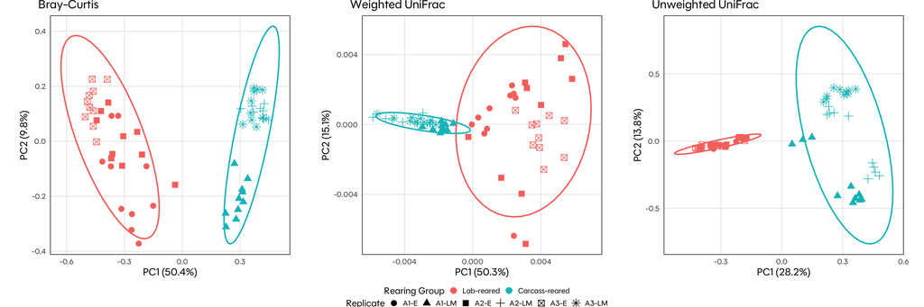

```r
# Create plots for Bray-Curtis
b1 <- ggplot(bray_df, aes(x = PC1, y = PC2, color = Rearing.Group, shape = Replicate)) +
  geom_point(size = 3) +
  # Add ellipses for rearing group
  stat_ellipse(aes(group = Rearing.Group), linewidth = 0.8) +
  labs(x = paste0("PC1 (", bray_var[1], "%)"),
       y = paste0("PC2 (", bray_var[2], "%)"),
       title = "Bray-Curtis") +
  # Ensure square aspect ratio
  coord_fixed(ratio = 1) +
  theme_minimal() +
  theme(
    text = element_text(family = "Polymath"),
    axis.text = element_text(family = "Polymath"),
    axis.title = element_text(face = "bold", size = 12, family = "Polymath"),
    plot.title = element_text(face = "bold", size = 14, family = "Polymath"),
    panel.border = element_rect(color = "black", fill = NA, linewidth = 0.6),
    panel.grid.minor = element_blank(),
    # Move both legends to bottom
    legend.position = "bottom",
    # Stack legends vertically
    legend.box = "vertical",
    legend.text = element_text(family = "Polymath"),
    legend.title = element_text(family = "Polymath")
  ) +
  guides(
    # Place both legends at the bottom in a row
    color = guide_legend(title = "Rearing Group", order = 1),
    shape = guide_legend(title = "Replicate", order = 2, nrow = 1)
  )

# Create plots for weighted UniFrac
w1 <- ggplot(w_df, aes(x = PC1, y = PC2, color = Rearing.Group, shape = Replicate)) +
  geom_point(size = 3) +
  # Add ellipses for rearing group
  stat_ellipse(aes(group = Rearing.Group), linewidth = 0.8) +
  labs(x = paste0("PC1 (", w_var[1], "%)"),
       y = paste0("PC2 (", w_var[2], "%)"),
       title = "Weighted UniFrac") +
  # Ensure square aspect ratio
  coord_fixed(ratio = 1) +
  theme_minimal() +
  theme(
    text = element_text(family = "Polymath"),
    axis.text = element_text(family = "Polymath"),
    axis.title = element_text(face = "bold", size = 12, family = "Polymath"),
    plot.title = element_text(face = "bold", size = 14, family = "Polymath"),
    panel.border = element_rect(color = "black", fill = NA, linewidth = 0.6),
    panel.grid.minor = element_blank(),
    # Move both legends to bottom
    legend.position = "bottom",
    # Stack legends vertically
    legend.box = "vertical",
    legend.text = element_text(family = "Polymath"),
    legend.title = element_text(family = "Polymath")
  ) +
  guides(
    # Place both legends at the bottom in a row
    color = guide_legend(title = "Rearing Group", order = 1),
    shape = guide_legend(title = "Replicate", order = 2, nrow = 1)
  )

# Create plots for unweighted UniFrac
uw1 <- ggplot(uw_df, aes(x = PC1, y = PC2, color = Rearing.Group, shape = Replicate)) +
  geom_point(size = 3) +
  # Add ellipses for rearing group
  stat_ellipse(aes(group = Rearing.Group), linewidth = 0.8) +
  labs(x = paste0("PC1 (", uw_var[1], "%)"),
       y = paste0("PC2 (", uw_var[2], "%)"),
       title = "Unweighted UniFrac") +
  # Ensure square aspect ratio
  coord_fixed() +
  theme_minimal() +
  theme(
    text = element_text(family = "Polymath"),
    axis.text = element_text(family = "Polymath"),
    axis.title = element_text(face = "bold", size = 12, family = "Polymath"),
    plot.title = element_text(face = "bold", size = 14, family = "Polymath"),
    panel.border = element_rect(color = "black", fill = NA, linewidth = 0.6),
    panel.grid.minor = element_blank(),
    # Move both legends to bottom
    legend.position = "bottom",
    # Stack legends vertically
    legend.box = "vertical",
    legend.text = element_text(family = "Polymath"),
    legend.title = element_text(family = "Polymath")
  ) +
  guides(
    # Place both legends at the bottom in a row
    color = guide_legend(title = "Rearing Group", order = 1),
    shape = guide_legend(title = "Replicate", order = 2, nrow = 1)
  )

# Combine plots with shared legends and ensure square aspect ratio
beta_plot <- (b1 + w1 + uw1) +
  plot_layout(guides = "collect", widths = c(1, 1, 1)) &
  theme(legend.position = "bottom",
        legend.box = "vertical",
        aspect.ratio = 1,  # Force square aspect ratio
        plot.margin = margin(t = 0, r = 5, b = 0, l = 5),  # Reduce bottom margin
        legend.margin = margin(t = -0.5, r = 0, b = -0.5, l = 0),  # Use more negative margins to bring legends closer
        legend.spacing.y = unit(.2, "cm"),  # Eliminate vertical spacing between legends
        legend.key.size = unit(0.7, "lines"),  # Make legend keys even smaller
        legend.key.height = unit(0.7, "lines"))  # Reduce legend key height

beta_plot
```

# Conclusion

The statistical tests confirmed these observations:

1. **Alpha diversity**: Wilcoxon rank-sum tests showed highly significant differences between rearing groups for all metrics.
2. **Beta diversity**: PERMANOVA tests indicated significant differences in community composition between rearing groups across all distance metrics.
3. **Beta dispersion**: Tests revealed significant differences in community dispersion for Bray-Curtis distances, but not for weighted UniFrac.

These findings suggest that the rearing environment substantially impacts the microbiome composition of blow fly larvae, which could have implications for their development, physiology, and potentially their forensic applications.